Max Wang  
PHYS 434  
HW3

```python
%matplotlib inline
import numpy as np
import matplotlib
import matplotlib.pyplot as plt
import scipy
from scipy import stats
import math

#this sets the size of the plot to something useful
plt.rcParams["figure.figsize"] = (20,15)
```

## Problem 0

Fake data initialization.

```python
t = np.linspace(0,np.pi*100,np.int(1e5))
N = 10+np.sin(t)
bkgd = stats.norm.rvs(size=np.int(1e5))*np.sqrt(N)+N
```

## Problem 1

a) Scatter plot of the first 1000 data points of the fake data.

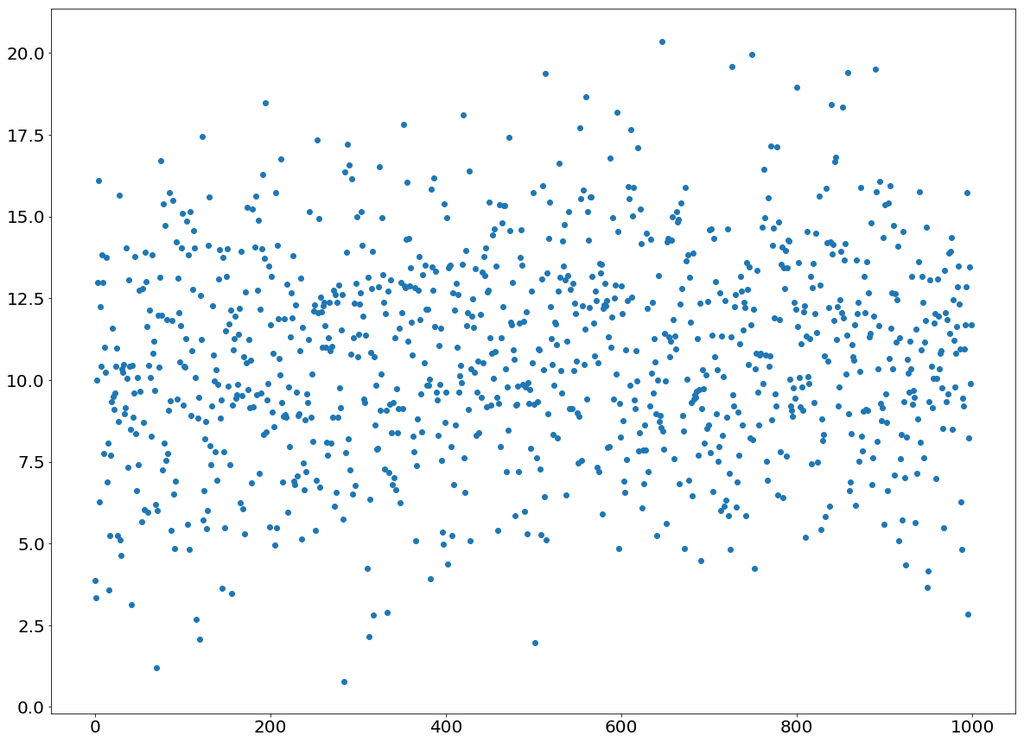

```python
plt.scatter(np.linspace(0, 999, 1000), bkgd[0:1000])
plt.tick_params(labelsize=20)
plt.show()
```

b) The below function creates a scatter plot ranging from start and end parameter, and the interval parameter dictates difference in ticks between each point of data.

```python
def subset(start, end, interval):
    x = np.linspace(start,end,int((end-start)/interval + 1))
    plt.scatter(x,bkgd[start:end+1:interval])
    plt.tick_params(labelsize=20)
    plt.show()
```

Scatter plot of fake data ranging from `x = 500:2500`.

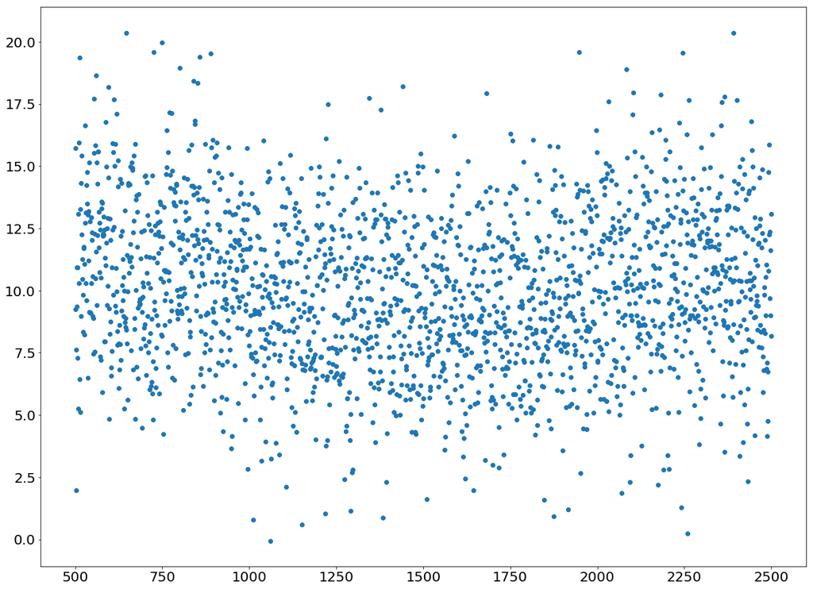

```python
subset(500, 2500, 1)
```

c) Scatter plot of fake data ranging from `x = 500:2500`, but only every 100th point.

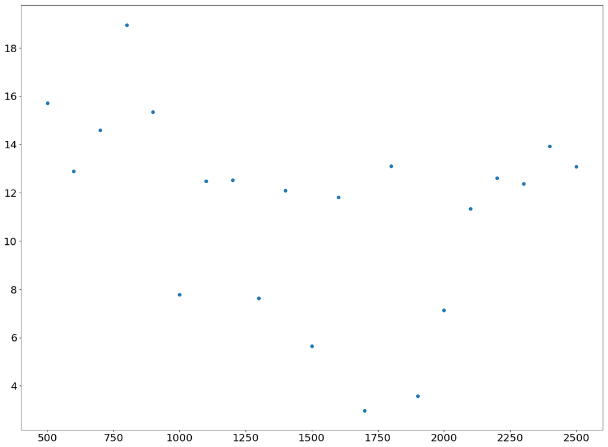

```python
subset(500, 2500, 100)
```

## Problem 2

As for the plot itself, the color of each bin represents the density of data points belonging to that bin. The more data points it contains, the more yellow it becomes. The colorbar on the size can be used to match the color with the approximate amount of data points in each bin, hence knowing the density of each bin.

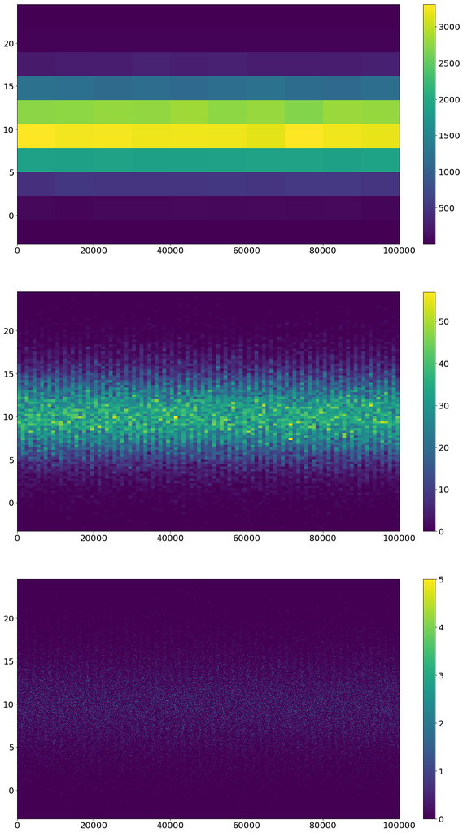

```python
x = np.linspace(0,len(bkgd)-1,len(bkgd))
fig, ax = plt.subplots(3,1,figsize=(20,35))
h, xe, ye, img = ax[0].hist2d(x,bkgd[0:100000],10)
cbar = plt.colorbar(img, ax=ax[0])
cbar.ax.tick_params(labelsize='20')
ax[0].tick_params(labelsize=20)
h, xe, ye, img = ax[1].hist2d(x,bkgd[0:100000],100)
cbar = plt.colorbar(img, ax=ax[1])
cbar.ax.tick_params(labelsize='20')
ax[1].tick_params(labelsize=20)
h, xe, ye, img = ax[2].hist2d(x,bkgd[0:100000],1000)
cbar = plt.colorbar(img, ax=ax[2])
cbar.ax.tick_params(labelsize='20')
ax[2].tick_params(labelsize=20)
plt.tick_params(labelsize=20)
plt.show()
```

## Problem 3

`new_t` is the time variable from problem 0 that has been folded at a period of `2π`. Below are the scatter plot and the density plot of the newly folded data. There is a more apparent sinusoidal shape in both plots compared to the old time variable.

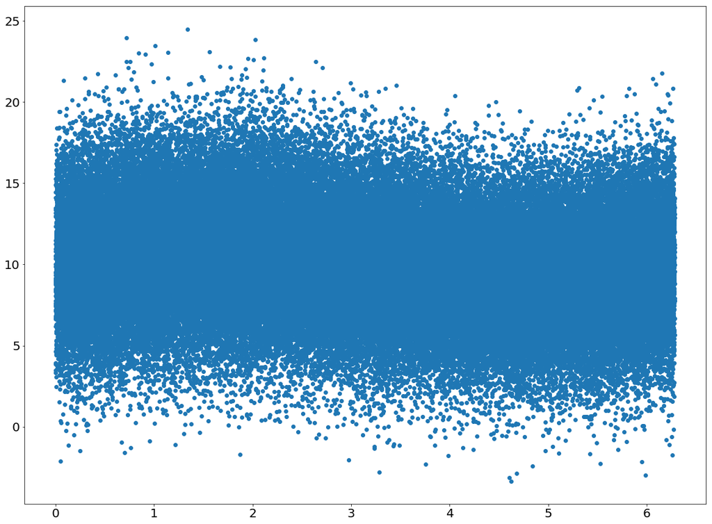

```python
new_t = t % (2 * math.pi)
plt.scatter(new_t, bkgd)
plt.tick_params(labelsize=20)
plt.show()
```

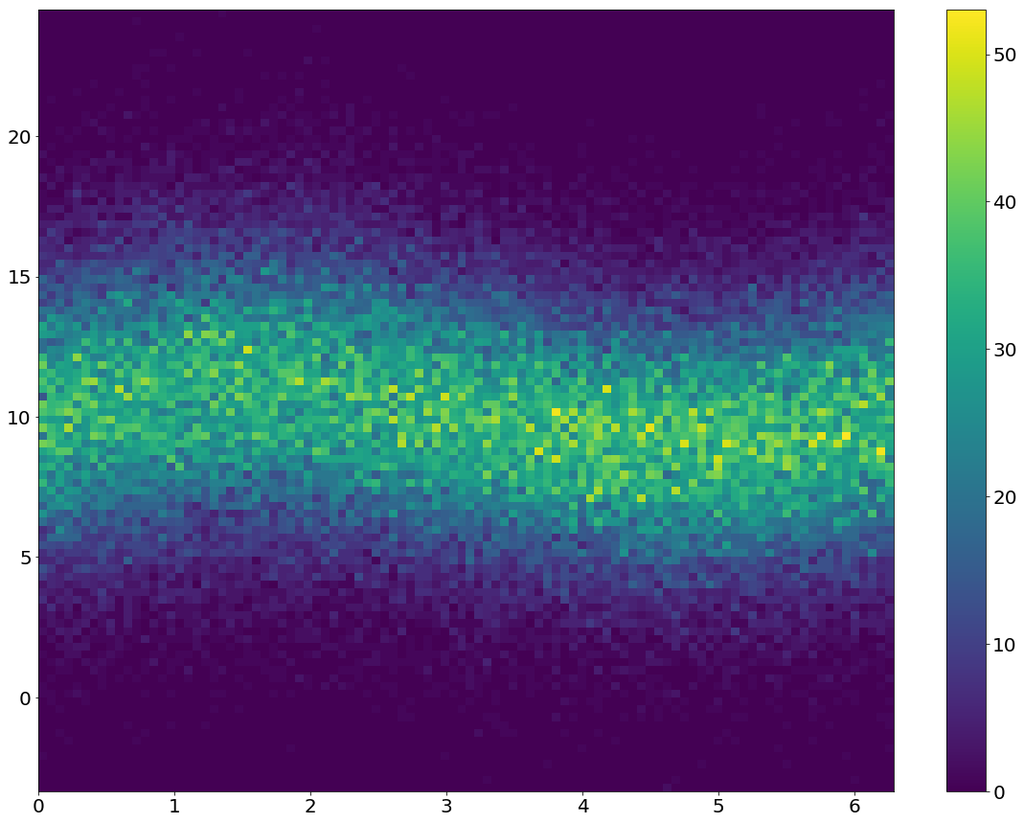

```python
plt.hist2d(new_t,bkgd,100)
cbar = plt.colorbar()
plt.tick_params(labelsize=20)
cbar.ax.tick_params(labelsize='20')
plt.show()
```